# Introduction to Inference and Confidence Intervals

Steve Elston

10/06/2022

# Tests of Significance

*“Critical tests of this kind may be called tests of significance, and when such tests are available we may discover whether a second sample is or is not significantly different from the first.”*

Ronald A. Fisher - 1925

# Introduction to Statistical Inference

All statistical inference has uncertainty

- Characterization of uncertainty is a goal of statistical inference
  - Any model using real-world data has inherent uncertainty
- Statistical inference seeks to avoid being [**fooled by randomness**](https://www.penguinrandomhouse.com/books/176225/fooled-by-randomness-by-nassim-nicholas-taleb/); A catchy title of a book
- A very few examples of false inference from randomness

| Hypothesis | Fooled by Randomness |
| --- | --- |
| How certain are you that eating fast food improves your health? | Some of my friends are doing great on this diet |
| How much confidence should we have that a marketing campaign increased sales? | Sales are up in the last month since the campaign started |
| How effective is a certain stock trading strategy for actually improving returns? | Traders using this strategy have made money recently |
| How good are the model parameter estimates? | The model has made accurate predictions so far |

# Applications of Statistical Inference

Confusingly, the term statistical inference is applied in many contexts

Some applications of statistical inference include:

**Inference on differences in distributions:** Are samples drawn from the same distribution or not? - A **null hypothesis** is the hypothesis that the distributions are the same

**Inference for model parameters and model selection:** Statistical models, including machine learning models, have unknown parameters for which the values must be estimated  
- Compute uncertainty in model parameter estimates  
- Compare model performance

**Inference for prediction:** In recent decades the distinction between prediction and classical inference has blurred to the point of being irrelevant  
- A common machine learning example, classification, uses decision rules determine the most likely class for each case of input values  
- inference also used to determine the confidence in predictions

# Types of Hypothesis Tests

- Different tests for **one sample**, **two samples** or more
- **Parametric** test uses assumptions about the distribution of the data
- **Non-parametric** tests make no distribution assumptions
- Select test for **discrete or continuous**, or **numeric or categorical**, **ordinal, interval, or ratio** variables
- Tests can compare **effect size** (averages), **variance**, **goodness of fit**, **distribution assumptions**, or **Independence**

# Inference for Hypotheses

**Hypothesis testing** seeks to answer the question, are the differences in a statistic **statistically significant**?

- Statistical significance must not be confused importance to the problem being addressed?

In 1922, Ronald A. Fisher warned:

*“I believe that no one who is familiar, either with mathematical advances in other fields, or with the range of special biological conditions to be considered, would ever conceive that everything could be summed up in a single mathematical formula, however complex.”*

# Inference for Hypotheses

Many statisticians would say that a statistically significant result indicates a relationship worthy of further investigation

Examples of further investigation include:

- Gather more data, either observational or experimental
- Find other variables which might illuminate the relationship under investigation
- Consider the theoretical basis of the relationship. E.G., can known science add understanding?

# Confidence Intervals; the Key to Inference

In frequentist statistics uncertainty of an inference is expressed in terms of a **confidence interval**

- A confidence interval is defined as the expected range of a statistical **point estimate**
  - A **point estimate** is the best estimate of a statistic
  - For example, the maximum likelihood estimate of a model parameter given the data
- Two types of of confidence intervals:
  - **Two-sided confidence intervals:** express confidence that a value is within some range around the point estimate
  - **One-sided confidence intervals:** express confidence that the point estimate is greater or less than some range of values

# Confidence Intervals; the Key to Inference

Can understand **two sided** confidence interval by looking at the $\alpha/2$ and $1 - \alpha/2$ quantiles of a distribution

- Confidence interval corresponds to the span of the distribution between quantiles
- Express a **two-sided confidence interval** for a random variable, $\mathbf{x}$, in terms of the probability as:

$$1- \alpha = P \Big( Lower\ CI \le
\mathbf{x} \le Upper\ CI \Big)$$

Example: For Normal distribution the right and left tail probabilities are $\alpha/2$:

$$\alpha/2 = P(x \le Lower\ CI),\ and,\
\alpha/2 = P(upper\ CI \ge x \ge \infty)$$

# Confidence Intervals; the Key to Inference

Can understand **one sided** confidence interval by looking at either $\alpha$ or $1 - \alpha$ quantiles of a distribution

- Characterize uncertainty of maximum or minimum value of a random variable
- For lower one-sided CI:

$$\alpha = P(x \le Lower\
CI)$$

- For upper one-sided CI:

$$1-\alpha = P(x \le Upper\
CI)$$

- Example: one-sided CIs of Normal distribution, starting with the lower CI:

$$\alpha = P\big( -\infty \le x \le lower\
CI \big)$$

Or for the upper confidence interval,

$$1- \alpha = P\big( -\infty \le x \le
upper\ CI \big)$$

Or,

$$\alpha = P(upper\ CI \ge x \ge
\infty)$$

# Example; confidence intervals of the Normal distribution

Illustrate the concept of confidence intervals with an example

- The **cumulative distribution function (CDF)** of a standard Normal distribution, $N(0,1)$
- Double ended arrows with annotation are plotted to illustrate the **two-sided 95% confidence interval** on the CDF
  - Horizontal double arrow shows the range of the confidence interval
  - Vertical double arrow shows the part of the distribution within the confidence intervals

```
## Confidence Interval, lower: -1.96, upper:  1.96
```

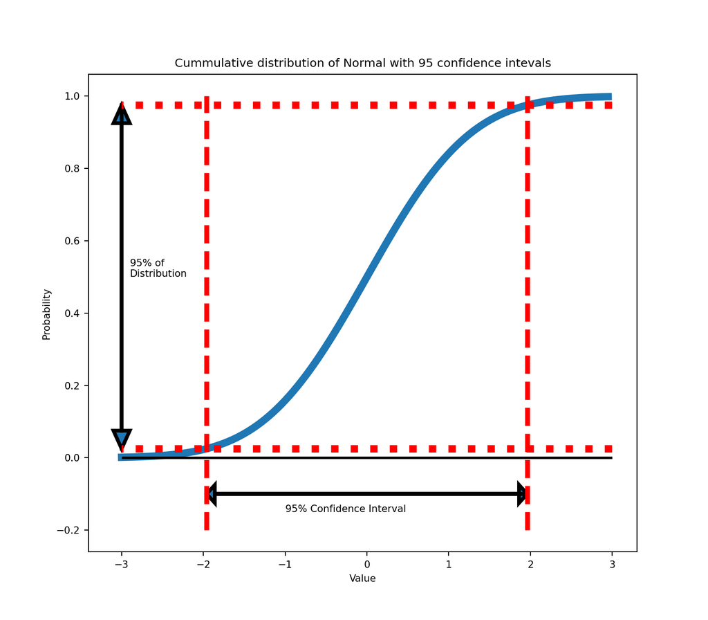

# Example, Inference for the mean

$$CI(mean) = CI(\bar{\mathbf{X}}) =
MLE(\theta | \mathbf{X})\ \pm\ \frac{s}{\sqrt{n}} Z_\alpha$$

Where,  
- $Z_\alpha$ is the standard Normal distribution evaluated at confidence level, $\alpha$  
- $MLE(\theta | \mathbf{X})$ is the maximum likelihood estiamte of the mean  
- Standard error is given by $s/ \sqrt{n}$  
- $s$ is the standard deviation estimate  
- $n$ is the number of samples

# Interpretation of Confidence Intervals

How can we interpret the confidence interval?

- Confidence intervals are with respect to the the sampling distribution of a statistic $s(\hat{\mathcal{F}})$
- CIs are a **measure of variation from sampling alone** with probability $\alpha$ - the basis of hypothesis testing!
- With probability $\alpha$ the sample statistic values computed from resamples of the population,$\hat{\mathcal{F}}_i$ are within the CI
- Confidence intervals do not indicate the probability $s(\hat{\mathcal{F}})$ is in a range

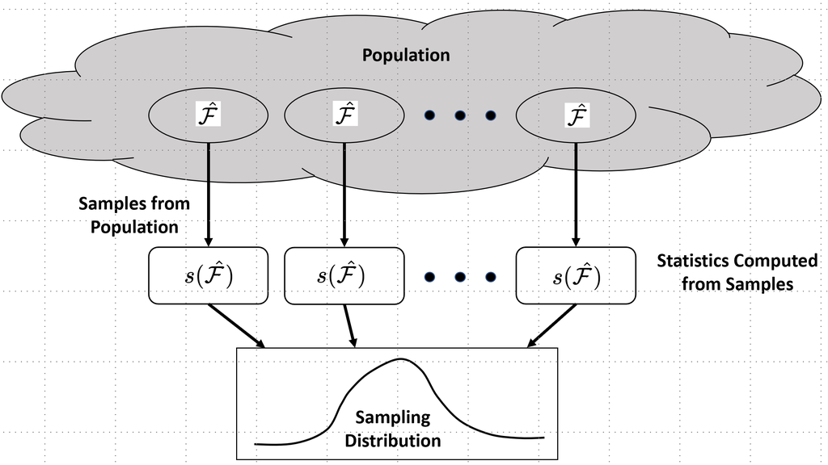

Sampling distribution of unknown population parameter

# Confidence and Hypothesis Testing

Purpose of a statistical test is determining if the value of a chosen test statistic exceeds a cutoff value

- Select the cutoff value based on the confidence we wish to have in the test result
  - Example, by specifying a cutoff of 0.05 we are saying that the probability that the test statistic **exceeding the cutoff from random variation alone** is 0.05
- Once the cutoff value has been set and the test statistic computed, interpret the results:
  - If the test statistic does not exceed the cutoff value, **fail to reject the null hypothesis**
  - If the test statistic exceeds the cutoff **reject the null hypothesis**

# Cutoffs for Hypothesis Tests

Examples of one-sided and two-sided cut-offs

- Cutoff is probability, $\alpha$, that **variation this great or greater arises from random sampling alone**
- In other words, cutoff is the **confidence** we have in rejecting a null hypothesis.
- A p-value is the **probability of the statistic this extreme or more extreme arising from random sampling** (random variation) alone

```
## (0.0, 1.0, 0.0, 1.0)
```

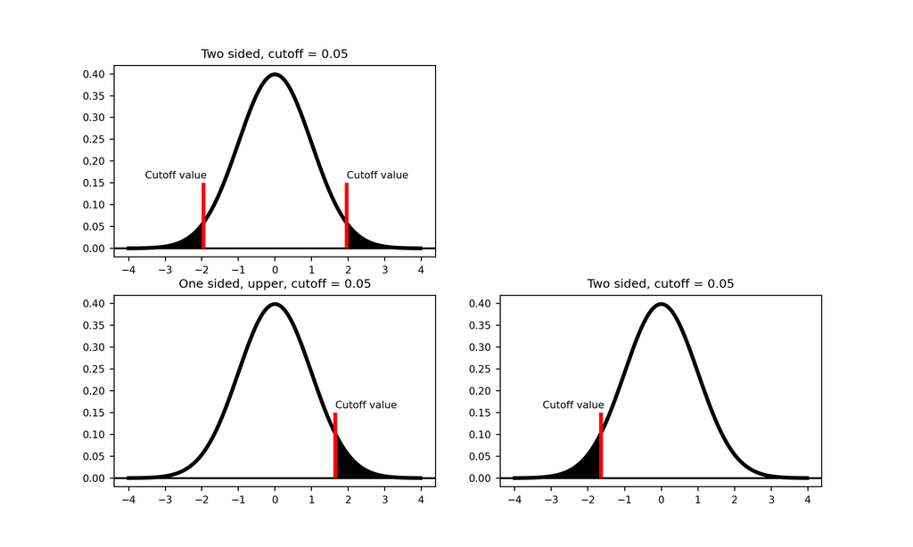

# Hypothesis testing steps

The steps required to perform a formal two-sample hypothesis test

- State population assumptions of null hypothesis: $H_0$
- State alternative hypothesis: $H_a$
  - Typically stated in terms of a **treatment group** vs. **control group**
  - Treatment is the factor that differentiates the population
- Decide on a significance level (probability cutoff or **Type I error threshold**): e.g. 0.1, 0.05, and 0.01
- Data is collected for the different treatments
  - Treatment used for comparison is the **control**
- Compute the **test statistic** and evaluate based on the cutoff value

# Hypothesis testing steps

Test statistic used a a **decision rule**

- Only two possible outcomes
  - **Reject the null-hypothesis:** This is not the same as accepting the alternative hypothesis
  - **Fail to reject the null hypothesis:** This is not the same as accepting the null hypothesis
- Failing to rejecting the null hypothesis can occur for several reasons
  - The alternative hypothesis was false to begin with
  - There is not enough evidence for the **effect size**
- Roughly speaking, the effect size is the difference of the test statistic in populations under the different treatments

# the p-value

- P-value is the probability, under $H_0$, that we get a statistic **as extreme or more extreme** than the one we got
- **Extreme** depends on whether the test is **one-tailed** or **two-tailed**
- Derive the p-value by computing the **statistic(s)** and evaluate the quantile of the null distribution, $H_0$
- Low p-value means our evidence against $H_0$ is too strong to ignore
  - How strong it needs to be is controlled by our choice of $\alpha$
  - **Smaller $\alpha$** means we need **stronger evidence** to reject $H_0$; a more **conservative** test
- Together the p-value and the significance threshold $\alpha$ determine whether we reject or fail to reject $H_0$
  - The decision rule of the hypothesis test

# A simple test of hypothesis

- say we have a random variable $X$ that follows an unknown distribution
- $H_0: \mu = 23, \sigma = 10$
- $H_1: \mu \ne 23, \sigma = 10$ and we choose $\alpha = 0.05$
- we collect a sample of size $17$ and compute the sample mean $\bar x = 20.2$
- by the CLT we know that $\bar X \sim N(\mu, \frac{\sigma}{\sqrt n}) = N(23, 10/\sqrt{17})$
- we refer to $N(23, 10/\sqrt{17})$ and look up the probability of getting $\bar x = 20.2$ or something more extreme (farther away from 23 than 20.2 is, in either direction because the test is two-tailed)
- we can look up the p-value in Python by running `2*scipy.stats.norm.cdf(20.2, loc = 23, scale = 10/np.sqrt(17)) -> 0.25` (we multiply by two because the test is two-tailed), so we fail to reject $H_0$

# Summary

Statistical inference seeks to characterize the uncertainty in estimates

- Statistics are estimates of population parameters
- Inferences using statistics must consider the uncertainty in the estimates
- Confidence intervals quantify uncertainty in statistical estimates
  - **Two-sided confidence intervals:** express confidence that a value is within some range around the point estimate
  - **One-sided confidence intervals:** express confidence that the point estimate is greater or less than some range of values
- Hypothesis tests based on the confidence we have that variation in statistic arrises from sampling variation alone